# Små biler — vægtet pointmodel

Billige, fabriksnye automatgear-biler

20 August 2026

## Sådan virker modellen

Dette er **søster-rapporten** til sammenligningen af de store (el)biler — samme vægtede pointmodel, men et andet felt og andre prioriteter.

**Felt:** små, *fabriksnye* biler, der kan fås med *automatgear* og har en *billig anskaffelse* (A/B-segment, benzin/hybrid). Ingen krav om elbil.

**Prioriteter** (kun tre, vægt 3 → 1):

1. **Samlet økonomi** (vægt 3)
2. **Driftsikkerhed** (vægt 2)
3. **Personsikkerhed** (vægt 1)

Modellens mekanik:

1. **Data** ligger i smaa_biler_specs.csv — én række pr. parameter, én kolonne pr. bil. Tilføj en bil = tilføj en kolonne; tilføj en parameter = tilføj en række.
2. Hver parameter har en **`kategori`** (én af de tre prioriteter, eller `info` = vises men tæller ikke med) og en **`retning`** (`hoej` = højere er bedst, `lav` = lavere er bedst).
3. **Normalisering pr. parameter (ratio-skala).** Den bedste bil får 1,0 og de øvrige proportionalt: for `hoej` er score $x/\max(x)$, for `lav` er $\min(x)/x$. Marginens størrelse bevares.
4. **Robust over for huller.** En parameter scorer, så længe mindst to biler har data; hver bils slutindeks normaliseres med vægten af de kategorier, bilen *har* data for.
5. **Kategoriscore** = gennemsnit af parameter-scorerne. **Slutindeks** = vægtet gennemsnit (vægte i smaa_biler_vaegte.csv), skaleret 0–100.

## Specifikationer (rådata)

Vandret scroll viser alle biler. `—` = ukendt/ikke udfyldt.

| Parameter | Enhed | Kia_Picanto | Dacia_Sandero | Fiat_Grande_Panda | Citroen_C3 | Toyota_AygoX | MG3 | Suzuki_Swift | Fiat_600 | Skoda_Fabia | Renault_Clio | Toyota_Yaris | VW_Polo | Kategori |
| --- | --- | --- | --- | --- | --- | --- | --- | --- | --- | --- | --- | --- | --- | --- |
| Pris | kr | 169.900 | 169.990 | 169.990 | 179.990 | 199.990 | 214.999 | 219.990 | 219.990 | 219.995 | 224.900 | 233.990 | 248.995 | oekonomi |
| Maerke | navn | Kia | Dacia | Fiat | Citroën | Toyota | MG | Suzuki | Fiat | Skoda | Renault | Toyota | VW | info |
| Doere | antal | 5 | 5 | 5 | 5 | 5 | 5 | 5 | 5 | 5 | 5 | 5 | 5 | info |
| Forbrug | km/l | 19,8 | 17,5 | 19,6 | 22 | 26 | 22,7 | 20,5 | 20,8 | 17,9 | 25,6 | 26,3 | 18,5 | info |
| Bagagerum | liter | 255 | 328 | 361 | 310 | 231 | 293 | 265 | 360 | 380 | 391 | 270 | 351 | info |
| Effekt_hk | hk | 63 | 90 | 110 | 100 | 116 | 194 | 82 | 100 | 110 | 160 | 116 | 95 | info |
| Garanti_bil_aar | aar | 7 | 3 | 8 | 8 | 10 | 7 | 3 | 8 | 2 | 2 | 10 | 2 | driftsikkerhed |
| Garanti_km | km | 150.000 | 100.000 | 160.000 | 160.000 | 185.000 | 150.000 | 100.000 | 160.000 | ubegrænset | ubegrænset | 185.000 | ubegrænset | info |
| NCAP_stjerner | stjerner | 3 | 2 | — | — | 4 | 4 | 3 | — | 5 | 4 | 5 | 5 | personsikkerhed |
| NCAP_adult | pct | 79 | 70 | — | — | 78 | 74 | 67 | — | 85 | 79 | 86 | 94 | info |
| NCAP_child | pct | 64 | 72 | — | — | 78 | 73 | 65 | — | 81 | 82 | 81 | 80 | info |
| NCAP_vru | pct | 54 | 41 | — | — | 74 | 81 | 76 | — | 70 | 80 | 78 | 70 | info |
| NCAP_safety_assist | pct | 25 | 42 | — | — | 81 | 69 | 62 | — | 71 | 73 | 85 | 70 | info |
| Vaerditab_pct_aar | pct | 8,8 | 11,6 | 7,4 | 9,2 | 10 | — | 11,1 | 7,4 | 12,2 | 10,8 | 10 | 14,2 | info |
| Vaerditab_4aar | kr | 52.364 | 66.182 | 45.002 | 57.643 | 68.777 | — | 82.583 | 58.239 | 89.260 | 82.520 | 80.469 | 114.055 | oekonomi |
| Drift_4aar | kr | 40.909 | 46.286 | 41.327 | 36.818 | 31.154 | 35.683 | 39.512 | 38.942 | 45.251 | 31.641 | 30.798 | 43.784 | oekonomi |

## Prioriteter og vægte

| Prioritet | Kategori | Vægt | Har data |
| --- | --- | --- | --- |
| 1 | Samlet økonomi | 3 | ja |
| 2 | Driftsikkerhed | 2 | ja |
| 3 | Personsikkerhed | 1 | ja |

## Kategoriscorer (0–100)

Hvor godt hver bil klarer hver prioritet, før vægtning.

| Kategori | Vægt | Kia_Picanto | Dacia_Sandero | Fiat_Grande_Panda | Citroen_C3 | Toyota_AygoX | MG3 | Suzuki_Swift | Fiat_600 | Skoda_Fabia | Renault_Clio | Toyota_Yaris | VW_Polo |
| --- | --- | --- | --- | --- | --- | --- | --- | --- | --- | --- | --- | --- | --- |
| Samlet økonomi | 3 | 87 | 78 | 91 | 85 | 83 | 83 | 70 | 78 | 65 | 76 | 76 | 59 |
| Driftsikkerhed | 2 | 70 | 30 | 80 | 80 | 100 | 70 | 30 | 80 | 20 | 20 | 100 | 20 |
| Personsikkerhed | 1 | 60 | 40 | — | — | 80 | 80 | 60 | — | 100 | 80 | 100 | 100 |

## Slutresultat

| Placering | Bil | Indeks | Datadækning |
| --- | --- | --- | --- |
| 1 | Toyota_AygoX | 88,2 | 3/3 |
| 2 | Toyota_Yaris | 88,1 | 3/3 |
| 3 | Fiat_Grande_Panda† | 86,9 | 2/3 |
| 4 | Citroen_C3† | 83,2 | 2/3 |
| 5 | Fiat_600† | 78,7 | 2/3 |
| 6 | MG3 | 78 | 3/3 |
| 7 | Kia_Picanto | 76,9 | 3/3 |
| 8 | Renault_Clio | 57,9 | 3/3 |
| 9 | Skoda_Fabia | 56 | 3/3 |
| 10 | Dacia_Sandero | 55,7 | 3/3 |
| 11 | Suzuki_Swift | 54,9 | 3/3 |
| 12 | VW_Polo | 53 | 3/3 |

*Datadækning* = antal vægtede kategorier bilen har data for (her højst 3).

† **Fodnote (Euro NCAP):** Fiat Grande Panda, Citroen C3, Fiat 600 er endnu ikke Euro NCAP-testede og scorer derfor *ikke* på personsikkerhed (datadækning 2/3). Da manglende data ikke straffes, løfter det dem relativt i indekset — de kan falde, når testresultater foreligger.

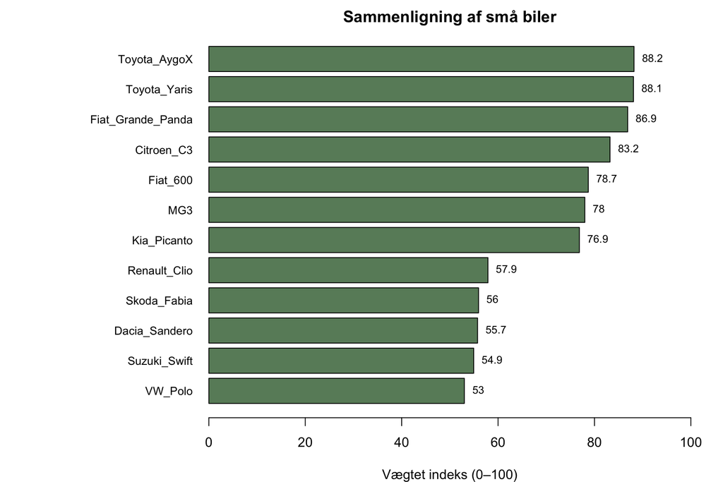

## Hvem vinder hver kategori

| Kategori | Vægt | Vinder |
| --- | --- | --- |
| Samlet økonomi | 3 | Fiat_Grande_Panda |
| Driftsikkerhed | 2 | Toyota_AygoX, Toyota_Yaris |
| Personsikkerhed | 1 | Skoda_Fabia, Toyota_Yaris, VW_Polo |

## Sådan opdaterer du

- **Ny værdi:** ret tallet i smaa_biler_specs.csv og knit igen.
- **Ny bil:** tilføj en kolonne i smaa_biler_specs.csv med bilens navn og værdier.
- **Ny parameter:** tilføj en række; sæt `kategori` (eller `info`) og `retning`.
- **Anden vægtning:** ret `vaegt` i smaa_biler_vaegte.csv.

Knit fra R: `rmarkdown::render("smaa_biler.Rmd")`.

## Datagrundlag og forbehold

**Krav til feltet:** alle biler er fabriksnye, fås med automatgear, har **5 døre** og er billige i anskaffelse (A/B-segment). Ingen krav om elbil — feltet er benzin/hybrid. (Kravene om *varmepumpe* og *forkonditionering af batteri* gælder kun elbiler og indgår derfor i søster-rapporten `smaa_elbiler`, ikke her.)

**Scorede parametre:** *Økonomi* = **totaløkonomi (TCO)** med tre lige-vægtede lav-parametre: anskaffelsespris + 4-års værditab (kr) + 4-års brændstof (kr). *Driftsikkerhed* = nybilsgaranti i år (høj). *Personsikkerhed* = Euro NCAP-stjerner (høj). Øvrige rækker (forbrug km/l, bagagerum, NCAP-delscorer, effekt, garanti-km, mærke, værditab-%) er `info`.

**Værditab (TCO).** `Vaerditab_4aar = Pris × (1−(1−r)⁴)`, hvor `r` er mærkets **benzin/hybrid-specifikke, mileage-justerede** afskrivning/år fra `depreciation_by_fueltype.csv` (genereret af `depreciation_by_fueltype.R` fra bilbasen-data — `analyze_depreciation.Rmd` er urørt). Raterne er empirisk-Bayes- krympet efter regressionens standardfejl. Brændstof = 60.000 km ÷ (km/l) × 13,5 kr/l. Antagelser (4 år, 15.000 km/år, brændstofpris) ændres i `tco`-chunken. Fueltype- splittet ændrer billedet vs. den samlede afskrivning (fx Kia: 8,8 % på benzin mod 15 % samlet, fordi Kias elbiler trak gennemsnittet op). **MG** mangler brugtmarked → værditab `—` (scorer kun på pris+brændstof).

**Valgte modeller** (billigste automatvariant — CVT/AMT/DSG/e-CVT): Kia Picanto · Dacia Sandero · Fiat Grande Panda Hybrid · Citroën C3 Hybrid · Toyota Aygo X Hybrid · MG3 Hybrid+ · Suzuki Swift · Fiat 600 Hybrid · Škoda Fabia · Renault Clio E-Tech · Toyota Yaris Hybrid · VW Polo.

**Ændringer ved opdateringen (august 2026):**

| Ændring | Bil | Årsag |
| --- | --- | --- |
| **Fjernet** | Hyundai i10 | Udgået — kan ikke købes fabriksny i DK (Hyundai DK: *tidligere modeller*) |
| **Fjernet** | Hyundai i20 | Udsolgt/udgået hos Hyundai DK |
| **Fjernet** | Peugeot 208 | Benzinversionen er udsolgt i Danmark |
| **Tilføjet** | Fiat Grande Panda Hybrid | Ny billig 5-dørs hybrid med eDCT-6 automat, 169.990 kr. |
| **Ny generation** | Renault Clio | Clio VI (2026): 160 hk E-Tech, 3,9 l/100 km ≈ 25,6 km/l — markant bedre end forgængeren |
| **Ny drivline** | Toyota Aygo X | Nu Hybrid (116 hk, ~26 km/l) — samme drivline som Yaris |
| **Pris op** | Toyota Yaris | 214.990 → 233.990 kr. |

**Bemærk om mikrobil-segmentet:** Hyundai i10 og Kia Picanto er begge udgået; **Toyota Aygo X er den eneste tilbageværende benzin-mikrobil** på det danske marked. Picanto er beholdt i tabellen, fordi den fortsat kan *bestilles* fabriksny (3–4 måneders leveringstid), men den er ved vejs ende.

**Kilder.** Priser, forbrug og garanti er danske vejledende 2026-tal fra importør-/forhandlersider og fagmedier; NCAP fra [Euro NCAP](https://www.euroncap.com).

**Forbehold:**

- Priser er **startpriser for billigste automatgear-variant** — verificér i konfiguratoren. Hvor en model kun fås med manuel i basis, er prisen for nærmeste automat-/DSG-/CVT-variant brugt.
- **Garanti** = den maksimale dækning, bilen kan opnå *uden tilkøb*. Da vi under alle omstændigheder overholder serviceintervallerne, skelnes der **ikke** mellem service-aktiveret og service-uafhængig garanti — begge tæller fuldt: Toyota Relax 10 år/185.000 km, Stellantis (Citroën/Peugeot/Fiat) 8 år/160.000 km, Kia/MG 7 år/150.000 km. Kun forlængelser der koster ekstra, tæller ikke med: fx **VW Polo** og **Renault Clio** (benzin) har 2 år, da de gratis 5-års-programmer hos VW/Renault/Škoda kun dækker elbiler. Garanti-km er kun info (ikke scoret), da flere har ubegrænset km.
- **NCAP** (stjerner + delscorer adult/child/VRU/safety-assist) stammer fra forskellige testår og -protokoller; ældre 5★ er ikke direkte sammenlignelige med nye. Kia Picanto er 2017-tal (**udløbet** rating); MG3’s 4★ fulgte en sjælden sædelås-fejl, som MG har udbedret via tilbagekald. Citroën C3, Fiat 600 og Fiat Grande Panda er ikke Euro NCAP-testede → `—` (se fodnoten ved slutresultatet).
- **Bagagerum** er fabrikstal (VDA, bagsæder oppe); enkelte (Swift, MG3, Fiat 600, C3, Grande Panda) er ca.-tal.
- **Data der bør efterprøves hos forhandler/producent:** forbruget for Fiat Grande Panda Hybrid er et estimat (~19,6 km/l); Renault Clio VI’s NCAP-stjerner er udledt af delscorerne (79/82/80/73) og bør verificeres; Škoda Fabias DSG-startpris varierer mellem prislisterne (194.995–245.000 kr. afhængigt af variant). Priserne i dette segment ændrer sig hurtigt. ```